# From Excel to Python: Using Pandas for Data Analysis

## Tristan McKenzie

### Dept. of Earth Sciences Tech Seminar

### October 29, 2019

## Why use Python Pandas over Microsoft Excel?

- Faster
- Less prone to human/software error
- Free
- More complicated analyses are easy to do

## Quick Python Tutorial

#### Installation & Running Python:

- [Anaconda Navigator](https://www.anaconda.com/)
- [Google Colaboratory (Colab)](https://colab.research.google.com)

#### Python's Library (HUGE!)

- composed of *packages*
- Pandas is an example of a Python package

## Importing packages into Python

Packages need to be imported - let's open Google Colab and do this now

```python
import pandas as pd
```

## What is Pandas?

Pandas = Python Data Analysis Library

Data Structures:

- [Series](https://pandas.pydata.org/pandas-docs/stable/reference/api/pandas.Series.html): like a single column or row in Excel
- [Data Frames](https://pandas.pydata.org/pandas-docs/stable/reference/frame.html): like the entire spreadsheet

```python
# creating a Series

s1 = (1, 2, 3)
s2 = (3, 4, 5)

series = pd.Series(s1)

print(series)
```

```
0    1
1    2
2    3
dtype: int64
```

```python
# creating a DataFrame

df = pd.DataFrame([s1,s2], columns = ['a', 'b', 'c'])

print(df)
```

```
   a  b  c
0  1  2  3
1  3  4  5
```

## Pandas Data Types

| Data Type | Description |
| --- | --- |
| object | strings (letters) |
| int64 | integers |
| float64 | floats (numbers with decimal points) |
| bool | Boolean (true/false) |
| datetime64 | Date and Time |

```python
# data types

df.dtypes
```

[output not shown]

```python
# creating another DataFrame with strings and integers

s3 = ('a', 'b', 'c')
s4 = (7, 8, 9)

df2 = pd.DataFrame([s3,s4])

print(df2)
```

```
   0  1  2
0  a  b  c
1  7  8  9
```

```python
df2.dtypes
```

```
0    object
1    object
2    object
dtype: object
```

## Loading and Saving External Files

**[Loading an Excel file](https://pandas.pydata.org/pandas-docs/stable/reference/api/pandas.read_excel.html)**

```
df = pd.read_excel('filepath/filename', sheet_name ='sheet name')
```

**[Loading a CSV file](https://pandas.pydata.org/pandas-docs/stable/reference/api/pandas.read_csv.html)**

```
df = pd.read_csv('filepath/filename', skiprows = #)
```

**[Saving an Excel file](https://pandas.pydata.org/pandas-docs/stable/reference/api/pandas.DataFrame.to_excel.html)**

```
df.to_excel('filepath/filename')
```

**[Saving a CSV file](https://pandas.pydata.org/pandas-docs/stable/reference/api/pandas.DataFrame.to_csv.html#pandas.DataFrame.to_csv)**

```
df.to_csv('filepath/filename')
```

## Viewing and Inspecting Data

**[First n rows](https://pandas.pydata.org/pandas-docs/stable/reference/api/pandas.DataFrame.head.html#pandas.DataFrame.head)**

```
df.head(n)
```

**[Last n rows](https://pandas.pydata.org/pandas-docs/stable/reference/api/pandas.DataFrame.tail.html#pandas.DataFrame.tail)**

```
df.tail(n)
```

**[Number of rows and columns](https://pandas.pydata.org/pandas-docs/stable/reference/api/pandas.DataFrame.shape.html#pandas.DataFrame.shape)**

```
df.shape
```

**[Index, datatype, memory info](https://pandas.pydata.org/pandas-docs/stable/reference/api/pandas.DataFrame.info.html)**

```
df.info()
```

## Loading data into Google Colab

```python
# Mounting Google Drive in your VM (instructions from Google)

from google.colab import drive
drive.mount('/gdrive')
```

```python
# Import PyDrive and associated libraries.
# This only needs to be done once per notebook.
from pydrive.auth import GoogleAuth
from pydrive.drive import GoogleDrive
from google.colab import auth
from oauth2client.client import GoogleCredentials

# Authenticate and create the PyDrive client.
# This only needs to be done once per notebook.
auth.authenticate_user()
gauth = GoogleAuth()
gauth.credentials = GoogleCredentials.get_application_default()
drive = GoogleDrive(gauth)

# Download a file based on its file ID.
#
# A file ID looks like: laggVyWshwcyP6kEI-y_W3P8D26sz
file_id = 'REPLACE_WITH_YOUR_FILE_ID'
downloaded = drive.CreateFile({'id': file_id})
print('Downloaded content "{}"'.format(downloaded.GetContentString()))
```

## Example: Mauna Loa Monthly Average $CO_2$ dataset

Download file [here](https://github.com/tamck/Pandas_tutorial/blob/master/co2_mm_mlo.csv)

Source: [NOAA Earth System Research Laboratory Global Monitoring Division](https://www.esrl.noaa.gov/gmd/ccgg/trends/data.html)(downloaded 10/17/19)

This dataset contains the monthly mean $CO_2$ mole fraction in parts per million (ppm) from March 1958 through September 2019 measured from the top of Mauna Loa.

**Tasks**:

- load csv
- view first 5 rows
- view last 5 rows

```python
CO2 = pd.read_csv("co2_mm_mlo.csv")
CO2 = pd.DataFrame(CO2, columns = ['Year', 'Month', 'Date', 'CO2_avg'])
CO2.head(5)
```

|  | Year | Month | Date | CO2_avg |
| --- | --- | --- | --- | --- |
| 0 | 1958 | 3 | 1958.208 | 315.71 |
| 1 | 1958 | 4 | 1958.292 | 317.45 |
| 2 | 1958 | 5 | 1958.375 | 317.50 |
| 3 | 1958 | 6 | 1958.458 | -99.99 |
| 4 | 1958 | 7 | 1958.542 | 315.86 |

```python
CO2.tail(5)
```

|  | Year | Month | Date | CO2_avg |
| --- | --- | --- | --- | --- |
| 734 | 2019 | 5 | 2019.375 | 414.66 |
| 735 | 2019 | 6 | 2019.458 | 413.92 |
| 736 | 2019 | 7 | 2019.542 | 411.77 |
| 737 | 2019 | 8 | 2019.625 | 409.95 |
| 738 | 2019 | 9 | 2019.708 | 408.54 |

## Indexing and Data Selection

**Indexing**: selecting specific rows/columns

`DataFrame['label']`= index columns by label

`DataFrame.loc['label']` = index by label

`DataFrame.iloc[#]` = index by position or integer

```python
# selecting a column based on label

CO2.loc[:,'Date']
```

```
0      1958.208
1      1958.292
2      1958.375
3      1958.458
4      1958.542
5      1958.625
6      1958.708
7      1958.792
8      1958.875
9      1958.958
10     1959.042
11     1959.125
12     1959.208
13     1959.292
14     1959.375
```

[output cut: 47 more lines]

```python
# selecting a column based on position

CO2.iloc[:,2]
```

```
0      1958.208
1      1958.292
2      1958.375
3      1958.458
4      1958.542
5      1958.625
6      1958.708
7      1958.792
8      1958.875
9      1958.958
10     1959.042
11     1959.125
12     1959.208
13     1959.292
14     1959.375
```

[output cut: 47 more lines]

```python
# selecting the same column

CO2['Date']
```

```
0      1958.208
1      1958.292
2      1958.375
3      1958.458
4      1958.542
5      1958.625
6      1958.708
7      1958.792
8      1958.875
9      1958.958
10     1959.042
11     1959.125
12     1959.208
13     1959.292
14     1959.375
```

[output cut: 47 more lines]

```python
# selecting multiple columns using the generic column indexer

CO2[['Date','CO2_avg']]
```

|  | Date | CO2_avg |
| --- | --- | --- |
| 0 | 1958.208 | 315.71 |
| 1 | 1958.292 | 317.45 |
| 2 | 1958.375 | 317.50 |
| 3 | 1958.458 | -99.99 |
| 4 | 1958.542 | 315.86 |
| 5 | 1958.625 | 314.93 |
| 6 | 1958.708 | 313.20 |
| 7 | 1958.792 | -99.99 |
| 8 | 1958.875 | 313.33 |
| 9 | 1958.958 | 314.67 |
| 10 | 1959.042 | 315.62 |
| 11 | 1959.125 | 316.38 |
| 12 | 1959.208 | 316.71 |
| 13 | 1959.292 | 317.72 |
| 14 | 1959.375 | 318.29 |
| 15 | 1959.458 | 318.15 |
| 16 | 1959.542 | 316.54 |
| 17 | 1959.625 | 314.80 |
| 18 | 1959.708 | 313.84 |
| 19 | 1959.792 | 313.26 |
| 20 | 1959.875 | 314.80 |
| 21 | 1959.958 | 315.58 |
| 22 | 1960.042 | 316.43 |
| 23 | 1960.125 | 316.97 |
| 24 | 1960.208 | 317.58 |
| 25 | 1960.292 | 319.02 |
| 26 | 1960.375 | 320.03 |
| 27 | 1960.458 | 319.59 |
| 28 | 1960.542 | 318.18 |
| 29 | 1960.625 | 315.91 |
| ... | ... | ... |
| 709 | 2017.292 | 409.04 |
| 710 | 2017.375 | 409.69 |
| 711 | 2017.458 | 408.88 |
| 712 | 2017.542 | 407.12 |
| 713 | 2017.625 | 405.13 |
| 714 | 2017.708 | 403.37 |
| 715 | 2017.792 | 403.63 |
| 716 | 2017.875 | 405.12 |
| 717 | 2017.958 | 406.81 |
| 718 | 2018.042 | 407.96 |
| 719 | 2018.125 | 408.32 |
| 720 | 2018.208 | 409.41 |
| 721 | 2018.292 | 410.24 |
| 722 | 2018.375 | 411.23 |
| 723 | 2018.458 | 410.79 |
| 724 | 2018.542 | 408.71 |
| 725 | 2018.625 | 406.99 |
| 726 | 2018.708 | 405.51 |
| 727 | 2018.792 | 406.00 |
| 728 | 2018.875 | 408.02 |
| 729 | 2018.958 | 409.07 |
| 730 | 2019.042 | 410.83 |
| 731 | 2019.125 | 411.75 |
| 732 | 2019.208 | 411.97 |
| 733 | 2019.292 | 413.32 |
| 734 | 2019.375 | 414.66 |
| 735 | 2019.458 | 413.92 |
| 736 | 2019.542 | 411.77 |
| 737 | 2019.625 | 409.95 |
| 738 | 2019.708 | 408.54 |

739 rows × 2 columns

```python
# selecting a row

CO2.iloc[2,:]
```

```
Year       1958.000
Month         5.000
Date       1958.375
CO2_avg     317.500
Name: 2, dtype: float64
```

```python
# selecting multiple columns

CO2.iloc[:,1:4]
```

|  | Month | Date | CO2_avg |
| --- | --- | --- | --- |
| 0 | 3 | 1958.208 | 315.71 |
| 1 | 4 | 1958.292 | 317.45 |
| 2 | 5 | 1958.375 | 317.50 |
| 3 | 6 | 1958.458 | -99.99 |
| 4 | 7 | 1958.542 | 315.86 |
| 5 | 8 | 1958.625 | 314.93 |
| 6 | 9 | 1958.708 | 313.20 |
| 7 | 10 | 1958.792 | -99.99 |
| 8 | 11 | 1958.875 | 313.33 |
| 9 | 12 | 1958.958 | 314.67 |
| 10 | 1 | 1959.042 | 315.62 |
| 11 | 2 | 1959.125 | 316.38 |
| 12 | 3 | 1959.208 | 316.71 |
| 13 | 4 | 1959.292 | 317.72 |
| 14 | 5 | 1959.375 | 318.29 |
| 15 | 6 | 1959.458 | 318.15 |
| 16 | 7 | 1959.542 | 316.54 |
| 17 | 8 | 1959.625 | 314.80 |
| 18 | 9 | 1959.708 | 313.84 |
| 19 | 10 | 1959.792 | 313.26 |
| 20 | 11 | 1959.875 | 314.80 |
| 21 | 12 | 1959.958 | 315.58 |
| 22 | 1 | 1960.042 | 316.43 |
| 23 | 2 | 1960.125 | 316.97 |
| 24 | 3 | 1960.208 | 317.58 |
| 25 | 4 | 1960.292 | 319.02 |
| 26 | 5 | 1960.375 | 320.03 |
| 27 | 6 | 1960.458 | 319.59 |
| 28 | 7 | 1960.542 | 318.18 |
| 29 | 8 | 1960.625 | 315.91 |
| ... | ... | ... | ... |
| 709 | 4 | 2017.292 | 409.04 |
| 710 | 5 | 2017.375 | 409.69 |
| 711 | 6 | 2017.458 | 408.88 |
| 712 | 7 | 2017.542 | 407.12 |
| 713 | 8 | 2017.625 | 405.13 |
| 714 | 9 | 2017.708 | 403.37 |
| 715 | 10 | 2017.792 | 403.63 |
| 716 | 11 | 2017.875 | 405.12 |
| 717 | 12 | 2017.958 | 406.81 |
| 718 | 1 | 2018.042 | 407.96 |
| 719 | 2 | 2018.125 | 408.32 |
| 720 | 3 | 2018.208 | 409.41 |
| 721 | 4 | 2018.292 | 410.24 |
| 722 | 5 | 2018.375 | 411.23 |
| 723 | 6 | 2018.458 | 410.79 |
| 724 | 7 | 2018.542 | 408.71 |
| 725 | 8 | 2018.625 | 406.99 |
| 726 | 9 | 2018.708 | 405.51 |
| 727 | 10 | 2018.792 | 406.00 |
| 728 | 11 | 2018.875 | 408.02 |
| 729 | 12 | 2018.958 | 409.07 |
| 730 | 1 | 2019.042 | 410.83 |
| 731 | 2 | 2019.125 | 411.75 |
| 732 | 3 | 2019.208 | 411.97 |
| 733 | 4 | 2019.292 | 413.32 |
| 734 | 5 | 2019.375 | 414.66 |
| 735 | 6 | 2019.458 | 413.92 |
| 736 | 7 | 2019.542 | 411.77 |
| 737 | 8 | 2019.625 | 409.95 |
| 738 | 9 | 2019.708 | 408.54 |

739 rows × 3 columns

```python
# selecting a specific cell

# select first element of first column
CO2.iloc[0,0]

# select specific date - later
```

## Indexing by Date and Time

- useful for temporal, time series data

`pd.to_datetime()`

```python
# create a new column that combines year and month and convert to datetime format
CO2['Date'] = pd.to_datetime(CO2[['Year', 'Month']].assign(Day = 1))

# indexing by time stamp, inplace = True means changes will occur in orignal dataframe
CO2.set_index(CO2['Date'], inplace = True)

CO2.head(5)
```

| Date | Year | Month | Date | CO2_avg |
| --- | --- | --- | --- | --- |
| 1958-03-01 | 1958 | 3 | 1958-03-01 | 315.71 |
| 1958-04-01 | 1958 | 4 | 1958-04-01 | 317.45 |
| 1958-05-01 | 1958 | 5 | 1958-05-01 | 317.50 |
| 1958-06-01 | 1958 | 6 | 1958-06-01 | -99.99 |
| 1958-07-01 | 1958 | 7 | 1958-07-01 | 315.86 |

## Dropping columns and rows

**Dropping entire columns or rows based on index**

`df.drop('Label', axis = 1)`

Axis = 1 for columns Axis = 0 for rows

**Dropping [entire rows](https://pandas.pydata.org/pandas-docs/stable/reference/api/pandas.DataFrame.dropna.html#pandas.DataFrame.dropna) because of missing values**

`df.dropna()`

**Dropping entire columns because of missing values**

`df.dropna(axis = 1)`

**Dropping a row based on value** `df[df.column != value]`

```python
# deleting the 'Date' column because data are now indexed by date
CO2 = CO2.drop('Date', axis = 1)

CO2.head(5)
```

| Date | Year | Month | CO2_avg |
| --- | --- | --- | --- |
| 1958-03-01 | 1958 | 3 | 315.71 |
| 1958-04-01 | 1958 | 4 | 317.45 |
| 1958-05-01 | 1958 | 5 | 317.50 |
| 1958-06-01 | 1958 | 6 | -99.99 |
| 1958-07-01 | 1958 | 7 | 315.86 |

```python
# deleting null values

CO2 = CO2[CO2.CO2_avg != -99.99]
```

## Filtering, Sorting, and Groupby

**sort column values into ascending order**

`df.sort_values(column)`

**sort column values into descending order**

`df.sort_values(column, ascending = False)`

**filtering (only column values with year greater than a certain value)**

`df[df[column] > value]`

**groupby**

`df.groupby(column)`

```python
# sort CO2 concentrations into ascending order

CO2_a = CO2.sort_values('CO2_avg')

print(CO2_a)
```

```
            Year  Month  CO2_avg
Date
1958-09-01  1958      9   313.20
1959-10-01  1959     10   313.26
1958-11-01  1958     11   313.33
1960-10-01  1960     10   313.83
1959-09-01  1959      9   313.84
1960-09-01  1960      9   314.16
1958-12-01  1958     12   314.67
1959-11-01  1959     11   314.80
1961-09-01  1961      9   314.80
1959-08-01  1959      8   314.80
1958-08-01  1958      8   314.93
1960-11-01  1960     11   315.00
1961-10-01  1961     10   315.38
1962-10-01  1962     10   315.42
1959-12-01  1959     12   315.58
1959-01-01  1959      1   315.62
1958-03-01  1958      3   315.71
1958-07-01  1958      7   315.86
1960-08-01  1960      8   315.91
1963-10-01  1963     10   315.99
1961-11-01  1961     11   316.10
1960-12-01  1960     12   316.19
1963-09-01  1963      9   316.21
1962-09-01  1962      9   316.26
1959-02-01  1959      2   316.38
1960-01-01  1960      1   316.43
1959-07-01  1959      7   316.54
1962-11-01  1962     11   316.69
1964-09-01  1964      9   316.70
1959-03-01  1959      3   316.71
...          ...    ...      ...
2017-01-01  2017      1   406.17
2017-02-01  2017      2   406.46
2017-12-01  2017     12   406.81
2016-06-01  2016      6   406.83
2018-08-01  2018      8   406.99
2017-07-01  2017      7   407.12
2017-03-01  2017      3   407.22
```

[output cut: 10 more lines]

```
2018-03-01  2018      3   409.41
2017-05-01  2017      5   409.69
2019-08-01  2019      8   409.95
2018-04-01  2018      4   410.24
2018-06-01  2018      6   410.79
2019-01-01  2019      1   410.83
2018-05-01  2018      5   411.23
2019-02-01  2019      2   411.75
2019-07-01  2019      7   411.77
2019-03-01  2019      3   411.97
2019-04-01  2019      4   413.32
2019-06-01  2019      6   413.92
2019-05-01  2019      5   414.66

[732 rows x 3 columns]
```

```python
# # sort CO2 concentrations into descending order

CO2_d = CO2.sort_values('CO2_avg', ascending = False)

print(CO2_d)
```

```
            Year  Month  CO2_avg
Date
2019-05-01  2019      5   414.66
2019-06-01  2019      6   413.92
2019-04-01  2019      4   413.32
2019-03-01  2019      3   411.97
2019-07-01  2019      7   411.77
2019-02-01  2019      2   411.75
2018-05-01  2018      5   411.23
2019-01-01  2019      1   410.83
2018-06-01  2018      6   410.79
2018-04-01  2018      4   410.24
2019-08-01  2019      8   409.95
2017-05-01  2017      5   409.69
2018-03-01  2018      3   409.41
2018-12-01  2018     12   409.07
2017-04-01  2017      4   409.04
2017-06-01  2017      6   408.88
2018-07-01  2018      7   408.71
2019-09-01  2019      9   408.54
2018-02-01  2018      2   408.32
2018-11-01  2018     11   408.02
2018-01-01  2018      1   407.96
2016-05-01  2016      5   407.72
2016-04-01  2016      4   407.45
2017-03-01  2017      3   407.22
2017-07-01  2017      7   407.12
2018-08-01  2018      8   406.99
2016-06-01  2016      6   406.83
2017-12-01  2017     12   406.81
2017-02-01  2017      2   406.46
2017-01-01  2017      1   406.17
...          ...    ...      ...
1959-03-01  1959      3   316.71
1964-09-01  1964      9   316.70
1962-11-01  1962     11   316.69
1959-07-01  1959      7   316.54
1960-01-01  1960      1   316.43
1959-02-01  1959      2   316.38
1962-09-01  1962      9   316.26
```

[output cut: 10 more lines]

```
1961-10-01  1961     10   315.38
1960-11-01  1960     11   315.00
1958-08-01  1958      8   314.93
1959-08-01  1959      8   314.80
1959-11-01  1959     11   314.80
1961-09-01  1961      9   314.80
1958-12-01  1958     12   314.67
1960-09-01  1960      9   314.16
1959-09-01  1959      9   313.84
1960-10-01  1960     10   313.83
1958-11-01  1958     11   313.33
1959-10-01  1959     10   313.26
1958-09-01  1958      9   313.20

[732 rows x 3 columns]
```

```python
# filter CO2_avg column for concentrations greater than 400 ppm
CO2[CO2['CO2_avg'] > 400]
```

| Date | Year | Month | CO2_avg |
| --- | --- | --- | --- |
| 2014-04-01 | 2014 | 4 | 401.38 |
| 2014-05-01 | 2014 | 5 | 401.78 |
| 2014-06-01 | 2014 | 6 | 401.25 |
| 2015-02-01 | 2015 | 2 | 400.28 |
| 2015-03-01 | 2015 | 3 | 401.54 |
| 2015-04-01 | 2015 | 4 | 403.28 |
| 2015-05-01 | 2015 | 5 | 403.96 |
| 2015-06-01 | 2015 | 6 | 402.80 |
| 2015-07-01 | 2015 | 7 | 401.31 |
| 2015-11-01 | 2015 | 11 | 400.16 |
| 2015-12-01 | 2015 | 12 | 401.85 |
| 2016-01-01 | 2016 | 1 | 402.56 |
| 2016-02-01 | 2016 | 2 | 404.12 |
| 2016-03-01 | 2016 | 3 | 404.87 |
| 2016-04-01 | 2016 | 4 | 407.45 |
| 2016-05-01 | 2016 | 5 | 407.72 |
| 2016-06-01 | 2016 | 6 | 406.83 |
| 2016-07-01 | 2016 | 7 | 404.41 |
| 2016-08-01 | 2016 | 8 | 402.27 |
| 2016-09-01 | 2016 | 9 | 401.05 |
| 2016-10-01 | 2016 | 10 | 401.59 |
| 2016-11-01 | 2016 | 11 | 403.55 |
| 2016-12-01 | 2016 | 12 | 404.45 |
| 2017-01-01 | 2017 | 1 | 406.17 |
| 2017-02-01 | 2017 | 2 | 406.46 |
| 2017-03-01 | 2017 | 3 | 407.22 |
| 2017-04-01 | 2017 | 4 | 409.04 |
| 2017-05-01 | 2017 | 5 | 409.69 |
| 2017-06-01 | 2017 | 6 | 408.88 |
| 2017-07-01 | 2017 | 7 | 407.12 |
| 2017-08-01 | 2017 | 8 | 405.13 |
| 2017-09-01 | 2017 | 9 | 403.37 |
| 2017-10-01 | 2017 | 10 | 403.63 |
| 2017-11-01 | 2017 | 11 | 405.12 |
| 2017-12-01 | 2017 | 12 | 406.81 |
| 2018-01-01 | 2018 | 1 | 407.96 |
| 2018-02-01 | 2018 | 2 | 408.32 |
| 2018-03-01 | 2018 | 3 | 409.41 |
| 2018-04-01 | 2018 | 4 | 410.24 |
| 2018-05-01 | 2018 | 5 | 411.23 |
| 2018-06-01 | 2018 | 6 | 410.79 |
| 2018-07-01 | 2018 | 7 | 408.71 |
| 2018-08-01 | 2018 | 8 | 406.99 |
| 2018-09-01 | 2018 | 9 | 405.51 |
| 2018-10-01 | 2018 | 10 | 406.00 |
| 2018-11-01 | 2018 | 11 | 408.02 |
| 2018-12-01 | 2018 | 12 | 409.07 |
| 2019-01-01 | 2019 | 1 | 410.83 |
| 2019-02-01 | 2019 | 2 | 411.75 |
| 2019-03-01 | 2019 | 3 | 411.97 |
| 2019-04-01 | 2019 | 4 | 413.32 |
| 2019-05-01 | 2019 | 5 | 414.66 |
| 2019-06-01 | 2019 | 6 | 413.92 |
| 2019-07-01 | 2019 | 7 | 411.77 |
| 2019-08-01 | 2019 | 8 | 409.95 |
| 2019-09-01 | 2019 | 9 | 408.54 |

## Basic Summary Statistics

**Summary stats**

[`df.describe()`](https://pandas.pydata.org/pandas-docs/stable/reference/api/pandas.DataFrame.describe.html#pandas.DataFrame.describe)

**Correlation between columns**

[`df.corr()`](https://pandas.pydata.org/pandas-docs/stable/reference/api/pandas.DataFrame.corr.html#pandas.DataFrame.corr)

**Other useful functions (all covered under summary stats)**

[`df.mean()`](https://pandas.pydata.org/pandas-docs/stable/reference/api/pandas.DataFrame.mean.html#pandas.DataFrame.mean)

[`df.count()`](https://pandas.pydata.org/pandas-docs/stable/reference/api/pandas.DataFrame.count.html#pandas.DataFrame.count)

[`df.max()`](https://pandas.pydata.org/pandas-docs/stable/reference/api/pandas.DataFrame.max.html#pandas.DataFrame.max)

[`df.min()`](https://pandas.pydata.org/pandas-docs/stable/reference/api/pandas.DataFrame.min.html#pandas.DataFrame.min)

[`df.median()`](https://pandas.pydata.org/pandas-docs/stable/reference/api/pandas.DataFrame.median.html#pandas.DataFrame.median)

[`df.std()`](https://pandas.pydata.org/pandas-docs/stable/reference/api/pandas.DataFrame.std.html#pandas.DataFrame.std)

```python
# summary stats for the whole dataframe

CO2.describe()
```

|  | Year | Month | CO2_avg |
| --- | --- | --- | --- |
| count | 732.000000 | 732.000000 | 732.000000 |
| mean | 1988.666667 | 6.501366 | 354.859085 |
| std | 17.727635 | 3.442909 | 28.123411 |
| min | 1958.000000 | 1.000000 | 313.200000 |
| 25% | 1973.000000 | 4.000000 | 329.112500 |
| 50% | 1989.000000 | 7.000000 | 352.375000 |
| 75% | 2004.000000 | 9.000000 | 377.565000 |
| max | 2019.000000 | 12.000000 | 414.660000 |

```python
# summary stats for just the 'CO2_avg' column

CO2['CO2_avg'].describe()
```

```
count    732.000000
mean     354.859085
std       28.123411
min      313.200000
25%      329.112500
50%      352.375000
75%      377.565000
max      414.660000
Name: CO2_avg, dtype: float64
```

```python
# correlation between columns for the dataframe

CO2.corr()
```

|  | Year | Month | CO2_avg |
| --- | --- | --- | --- |
| Year | 1.000000 | -0.018371 | 0.989209 |
| Month | -0.018371 | 1.000000 | -0.050321 |
| CO2_avg | 0.989209 | -0.050321 | 1.000000 |

## Brief Intro to Plotting in Python

[Matplotlib](https://matplotlib.org/) Package = similar plotting to MATLAB

- similar functionality to MATLAB plotting, i.e. subplots, data visualization, etc.

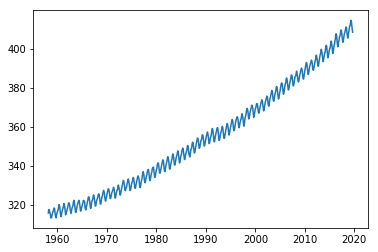

```python
# creating a simple plot

import matplotlib.pyplot as plt
%matplotlib inline

plt.plot(CO2['CO2_avg'])
```

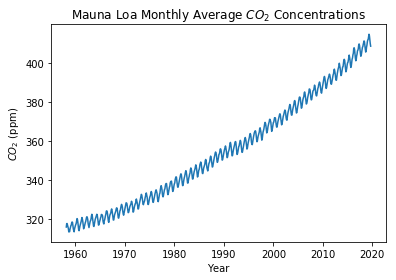

```python
plt.plot(CO2['CO2_avg'])
plt.title('Mauna Loa Monthly Average $CO_2$ Concentrations')
plt.xlabel('Year')
plt.ylabel('$CO_2$ (ppm)')
```

## Pivot Tables

- allow for quick summarization of data

**Creating a [pivot table](https://pandas.pydata.org/pandas-docs/stable/reference/api/pandas.pivot_table.html) in Pandas**

`pd.pivot_table(data, values = '', index = '', columns = [col names])`

Example from [here](https://towardsdatascience.com/intro-to-pandas-for-excel-super-users-dac1b38f12b0) using Chicago Public Schools 2016-2017 Progress Report data

Download datasets [here](https://github.com/tamck/Pandas_tutorial/blob/master/Chicago_Public_Schools_-_School_Progress_Reports_SY1516.csv) and [here](https://github.com/tamck/Pandas_tutorial/blob/master/Chicago_Public_Schools_-_School_Progress_Reports_SY1617.csv)

```python
# load dataset
sy1617 = pd.read_csv('Chicago_Public_Schools_-_School_Progress_Reports_SY1617.csv', index_col='School_ID')

sy1617.head()
```

| School_ID | Short_Name | Long_Name | School_Type | Primary_Category | Address | City | State | Zip | Phone | Fax | ... | Supportive_School_Award_Desc | Parent_Survey_Results_Year | School_Latitude | School_Longitude | Location | Community Areas | Zip Codes | Boundaries - ZIP Codes | Census Tracts | Wards |
| --- | --- | --- | --- | --- | --- | --- | --- | --- | --- | --- | --- | --- | --- | --- | --- | --- | --- | --- | --- | --- | --- |
| 610104 | ONAHAN | William J Onahan Elementary School | Neighborhood | ES | 6634 W RAVEN ST | Chicago | Illinois | 60631 | 7735341180 | 7.735341e+09 | ... | This school has been rated Established for its... | 2016.0 | 41.993790 | -87.793108 | 6634 W RAVEN ST\nChicago, Illinois 60631\n(41.... | 36 | 22243 | 17 | 657 | 29 |
| 610390 | RICKOVER MILITARY HS | Hyman G Rickover Naval Academy High School | Military academy | HS | 5900 N GLENWOOD AVE | Chicago | Illinois | 60660 | 7735342890 | 7.735343e+09 | ... | This school has been rated Established for its... | 2016.0 | 41.989021 | -87.665789 | 5900 N GLENWOOD AVE\nChicago, Illinois 60660\n... | 76 | 4451 | 14 | 539 | 16 |
| 610070 | MCPHERSON | James B McPherson Elementary School | Neighborhood | ES | 4728 N WOLCOTT AVE | Chicago | Illinois | 60640 | 7735342625 | 7.735343e+09 | ... | This school is in the process of being reviewe... | 2016.0 | 41.967847 | -87.676288 | 4728 N WOLCOTT AVE\nChicago, Illinois 60640\n(... | 6 | 22616 | 15 | 225 | 18 |
| 400117 | NOBLE - HANSBERRY HS | Noble - Hansberry College Prep | Charter | HS | 8748 S ABERDEEN ST | Chicago | Illinois | 60620 | 7737293400 | 7.733042e+09 | ... | This school is in the process of being reviewe... | 2016.0 | 41.734442 | -87.650987 | 8748 S ABERDEEN ST\nChicago, Illinois 60620\n(... | 70 | 21554 | 59 | 533 | 13 |
| 610251 | CATHER | Willa Cather Elementary School | Neighborhood | ES | 2908 W WASHINGTON BLVD | Chicago | Illinois | 60612 | 7735346780 | 7.735347e+09 | ... | This school is in the process of being reviewe... | 2016.0 | 41.882950 | -87.699187 | 2908 W WASHINGTON BLVD\nChicago, Illinois 6061... | 28 | 21184 | 28 | 50 | 46 |

5 rows × 165 columns

```python
# Pivot Tables in Pandas

# create pivot table that groups school type (rows) and primary category (columns) and calculates average student response rate
pd.pivot_table(sy1617, values='School_Survey_Student_Response_Rate_Pct', index='School_Type', columns=['Primary_Category'], aggfunc=np.mean)

#CO2_pivot = pd.pivot_table(CO2, columns =  ['Month','CO2_avg'])
```

| Primary_Category School_Type | ES | HS | MS |
| --- | --- | --- | --- |
| Career academy | NaN | 65.375000 | NaN |
| Charter | 66.033333 | 69.556061 | 99.400000 |
| Citywide-Option | 0.000000 | 65.235000 | NaN |
| Classical | 98.320000 | NaN | NaN |
| Contract | 45.700000 | 84.450000 | NaN |
| Magnet | 88.722222 | 84.342857 | NaN |
| Military academy | NaN | 87.883333 | NaN |
| Neighborhood | 84.537681 | 80.424444 | 93.814286 |
| Regional gifted center | 93.380000 | NaN | NaN |
| Selective enrollment | NaN | 82.190909 | NaN |
| Small | 87.466667 | 77.571429 | NaN |
| Special Education | 0.000000 | 58.125000 | NaN |

## VLOOKUP

In Excel, VLOOKUP looks for a specific value in a range of cells and then returns a value that is in the same row as where the value that is being searched is located - it's very useful for merging large datasets.

In the following example, we will search by school ID and compare student attainment ratings from both the 2015-2016 and 2016-2017 school years (example from from [here](https://towardsdatascience.com/intro-to-pandas-for-excel-super-users-dac1b38f12b0).

```python
# Emulating VLOOKUP in Pandas

# read in the csv for prior year's data
sy1516 = pd.read_csv('Chicago_Public_Schools_-_School_Progress_Reports_SY1516.csv', index_col='School_ID')


sy1617_short = sy1617[['Student_Attainment_Rating', 'Long_Name']]
sy1516_short = sy1516[['Student_Attainment_Rating']]

# merge function allows the two datasets to be merged by their indicies, School_ID
pd.merge(sy1516_short, sy1617_short, how='right', left_index=True, right_index=True, suffixes=('_1516','_1617'))
sy1617_short.join(sy1516_short, how='left', lsuffix='_1617', rsuffix='_1516')
```

| School_ID | Student_Attainment_Rating_1617 | Long_Name | Student_Attainment_Rating_1516 |
| --- | --- | --- | --- |
| 610104 | ABOVE AVERAGE | William J Onahan Elementary School | FAR ABOVE AVERAGE |
| 610390 | BELOW AVERAGE | Hyman G Rickover Naval Academy High School | AVERAGE |
| 610070 | AVERAGE | James B McPherson Elementary School | AVERAGE |
| 400117 | AVERAGE | Noble - Hansberry College Prep | AVERAGE |
| 610251 | AVERAGE | Willa Cather Elementary School | AVERAGE |
| 610268 | BELOW AVERAGE | Arthur R Ashe Elementary School | BELOW AVERAGE |
| 610089 | AVERAGE | John B Murphy Elementary School | ABOVE AVERAGE |
| 610158 | AVERAGE | Harriet E Sayre Elementary Language Academy | ABOVE AVERAGE |
| 609866 | FAR ABOVE AVERAGE | John C Coonley Elementary School | FAR ABOVE AVERAGE |
| 610218 | AVERAGE | Joseph Warren Elementary School | AVERAGE |
| 610090 | ABOVE AVERAGE | Phillip Murray Elementary Language Academy | ABOVE AVERAGE |
| 609986 | BELOW AVERAGE | Charles R Henderson Elementary School | FAR BELOW AVERAGE |
| 400046 | AVERAGE | L.E.A.R.N. - Romano Butler Campus | ABOVE AVERAGE |
| 610128 | AVERAGE | Marcus Moziah Garvey Elementary School | AVERAGE |
| 610116 | AVERAGE | Parkside Elementary Community Academy | BELOW AVERAGE |
| 609971 | BELOW AVERAGE | John Harvard Elementary School of Excellence | BELOW AVERAGE |
| 610291 | AVERAGE | Richard Henry Lee Elementary School | AVERAGE |
| 609967 | BELOW AVERAGE | William F Finkl Elementary School | BELOW AVERAGE |
| 609737 | AVERAGE | Friedrich W von Steuben Metropolitan Science HS | AVERAGE |
| 610141 | ABOVE AVERAGE | Ravenswood Elementary School | FAR ABOVE AVERAGE |
| 609859 | ABOVE AVERAGE | DeWitt Clinton Elementary School | FAR ABOVE AVERAGE |
| 400175 | FAR BELOW AVERAGE | Excel - Woodlawn HS | FAR BELOW AVERAGE |
| 610221 | AVERAGE | Daniel Webster Elementary School | BELOW AVERAGE |
| 400141 | BELOW AVERAGE | YCCS-Truman Middle College HS | NO DATA AVAILABLE |
| 609870 | AVERAGE | Daniel J Corkery Elementary School | AVERAGE |
| 609732 | BELOW AVERAGE | Charles P Steinmetz College Preparatory HS | BELOW AVERAGE |
| 609798 | ABOVE AVERAGE | Hiram H Belding Elementary School | ABOVE AVERAGE |
| 610581 | FAR BELOW AVERAGE | Magic Johnson- Brainerd HS | NO DATA AVAILABLE |
| 610185 | AVERAGE | Adlai E Stevenson Elementary School | ABOVE AVERAGE |
| 609780 | BELOW AVERAGE | Marine Leadership Academy at Ames | AVERAGE |
| ... | ... | ... | ... |
| 400149 | BELOW AVERAGE | Acero Charter Schools - Victoria Soto | NO DATA AVAILABLE |
| 400114 | ABOVE AVERAGE | Acero Charter Schools - Esmeralda Santiago | ABOVE AVERAGE |
| 400084 | AVERAGE | Acero Charter Schools - Rufino Tamayo | AVERAGE |
| 609949 | AVERAGE | William P Gray Elementary School | ABOVE AVERAGE |
| 400085 | BELOW AVERAGE | Acero Charter Schools - Major Hector P. Garcia MD | BELOW AVERAGE |
| 400101 | ABOVE AVERAGE | Acero Charter Schools - Sandra Cisneros | ABOVE AVERAGE |
| 400121 | AVERAGE | Acero Charter Schools - Sor Juana Inés de la Cruz | AVERAGE |
| 400080 | ABOVE AVERAGE | Acero Charter Schools - PFC Omar E. Torres | ABOVE AVERAGE |
| 400089 | AVERAGE | Acero Charter Schools - Officer Donald J. Marquez | ABOVE AVERAGE |
| 610163 | NO DATA AVAILABLE | Frederick Stock Elementary School | NO DATA AVAILABLE |
| 400129 | FAR BELOW AVERAGE | YCCS-Progressive Leadership Academy | NO DATA AVAILABLE |
| 400022 | AVERAGE | Chicago High School for the Arts (ChiArts) | AVERAGE |
| 400164 | NO DATA AVAILABLE | Instituto - Justice Lozano Mastery | NO DATA AVAILABLE |
| 610565 | FAR BELOW AVERAGE | Excel - Englewood HS | FAR BELOW AVERAGE |
| 400163 | AVERAGE | KIPP Chicago Charter School - KIPP Bloom | AVERAGE |
| 400146 | AVERAGE | KIPP Chicago Charter School - KIPP Create | AVERAGE |
| 400075 | AVERAGE | University of Chicago - Donoghue | ABOVE AVERAGE |
| 610572 | NO DATA AVAILABLE | Camelot Safe Elementary | NO DATA AVAILABLE |
| 400147 | NO DATA AVAILABLE | Chicago Excel Academy | FAR BELOW AVERAGE |
| 400137 | FAR BELOW AVERAGE | Little Black Pearl Art and Design Academy | BELOW AVERAGE |
| 610573 | NO DATA AVAILABLE | Camelot Safe HS | NO DATA AVAILABLE |
| 400180 | NO DATA AVAILABLE | KIPP One Academy | NaN |
| 400170 | NO DATA AVAILABLE | Noble - The Noble Academy | NO DATA AVAILABLE |
| 610121 | AVERAGE | Washington Irving Elementary School | AVERAGE |
| 400021 | BELOW AVERAGE | Catalyst Elementary Charter School - Circle Rock | BELOW AVERAGE |
| 400048 | BELOW AVERAGE | L.E.A.R.N. - Excel Campus | BELOW AVERAGE |
| 609821 | AVERAGE | Burnham Elementary Inclusive Academy | AVERAGE |
| 609723 | BELOW AVERAGE | John Marshall Metropolitan High School | BELOW AVERAGE |
| 610305 | BELOW AVERAGE | George Leland Elementary School | FAR BELOW AVERAGE |
| 609874 | ABOVE AVERAGE | Everett McKinley Dirksen Elementary School | FAR ABOVE AVERAGE |

661 rows × 3 columns

## Time Stamps

A **time stamp** (a specific point in time) element in `Pandas` can be created using the following syntax:

`pd.Timestamp()`

The time stamp 'January 2, 2018' can be specified with `Pandas` in one of three ways:

`1. pd.Timestamp(datetime(2018, 1, 2))`

`2. pd.Timestamp('2018-01-02')`

`3. pd.Timestamp(2018, 1, 2)`

```python
# time stamps in pandas
from datetime import datetime

# create a time stamp element in pandas
timestamp1 = pd.Timestamp(datetime(2018, 1, 2))
print(timestamp1)

timestamp2 = pd.Timestamp('2018-01-02')
print(timestamp2)

timestamp3 = pd.Timestamp(2018, 1, 2)
print(timestamp3)
```

```
2018-01-02 00:00:00
2018-01-02 00:00:00
2018-01-02 00:00:00
```

## Can also specify time

The time stamp 'January 2, 2018 4:04:00 pm' can be specified with `Pandas` as follows:

1. `pd.Timestamp(datetime(2018, 1, 2, 16, 4, 0))`
2. `pd.Timestamp('2018-01-02 16:04:00')`
3. `pd.Timestamp(2018, 1, 2, 16, 4, 0)`

```python
# time stamp elements in pandas (cont)
timestamp4 = pd.Timestamp(datetime(2018, 1, 2, 16, 4, 0))
print(timestamp4)

timestamp5 = pd.Timestamp('2018-01-02 16:04:00')
print(timestamp5)

timestamp6 = pd.Timestamp(2018, 1, 2, 16, 4, 0)
print(timestamp6)
```

```
2018-01-02 16:04:00
2018-01-02 16:04:00
2018-01-02 16:04:00
```

## Time Intervals

A **time interval** element in `Pandas` can be created using the following syntax:

`pd.Period()`

The time interval 'January 2018' can be specified with pandas in one of two ways:

1. `pd.Period('2018-01')`
2. `pd.Period('2018-01', freq = 'M')```

Where 'freq' refers to the frequency of the interval.

```python
# period elements in pandas

period1 = pd.Period('2018-01')
print(period1)

period2 = pd.Period('2018-01', freq = 'M')
print(period2)
```

```
2018-01
2018-01
```

`Pandas` has the following aliases for the specified periods:

| **Period** | **Frequency** |
| --- | --- |
| hour | H |
| day | D |
| week | W |
| month | M |
| year | Y |

## Time Deltas

A **time delta** element can be created by finding the difference between two date, time, or `datetime` elements.

```python
# time delta between two datetime objects using arithmetic

t1 = pd.Timestamp(datetime(2018, 1, 2, 16, 4, 0))
t2 = pd.Timestamp(datetime(2017, 2, 5, 14, 2, 5))

timedelta = t1 - t2

print(timedelta)
```

```
331 days 02:01:55
```

## Other Useful Functions

### Join/Combine

**add the rows in df1 to the end of df2 (must have identical columns)** `df1.append(df2)`

**add the columns in df1 to the end of df2 (must have identical rows)** `df.concat([df1, df2], axis = 1)`

### Renaming columns

`df.rename(columns = {'old_name': 'new_name'})`

`df.set_index('column_one')`

**arithmetic** `df['total'] = df['Jan'] + df['Feb'] + df['Mar']`

### Converting string data to datetime format

`datetime_conv = pd.to_datetime(pd.Series(['Jan 01, 2018', '2018-12-31']))`

## Additional Resources

[Pandas Documentation](https://pandas.pydata.org/pandas-docs/stable/index.html)

[Additional DataFrame functions in Pandas](https://pandas.pydata.org/pandas-docs/stable/reference/frame.html#attributes-and-underlying-data)

[Pivot Tables Tutorial](https://www.dataquest.io/blog/pandas-pivot-table/)

[Intro to Pandas for Excel Super Users](https://towardsdatascience.com/intro-to-pandas-for-excel-super-users-dac1b38f12b0)

[Creating slides using Jupyter Notebooks](https://medium.com/learning-machine-learning/present-your-data-science-projects-with-jupyter-slides-75f20735eb0f)